# Chapter 5: Dimensionality reduction

load required libraries

```r
library(tidyverse)
library(psych)
```

```r
library(corrplot)
library(tibble)
library(FactoMineR)
```

### Part 1: Overview

Read the data on transpose columns to rows

```r
human = read.csv('data/human.csv',header = TRUE)
human_ <- column_to_rownames(human, "Country")
```

Check the distributions and correlations between variables

```r
describe(human)
```

```
##           vars   n     mean       sd   median  trimmed      mad    min
## Country*     1 155    78.00    44.89    78.00    78.00    57.82   1.00
## Edu2.FM      2 155     0.85     0.24     0.94     0.87     0.12   0.17
## Labo.FM      3 155     0.71     0.20     0.75     0.73     0.17   0.19
## Life.Exp     4 155    71.65     8.33    74.20    72.40     7.56  49.00
## Edu.Exp      5 155    13.18     2.84    13.50    13.24     2.97   5.40
## GNI          6 155 17627.90 18543.85 12040.00 14552.58 13337.47 581.00
## Mat.Mor      7 155   149.08   211.79    49.00   104.70    63.75   1.00
## Ado.Birth    8 155    47.16    41.11    33.60    41.62    35.73   0.60
## Parli.F      9 155    20.91    11.49    19.30    20.32    11.42   0.00
##                 max     range  skew kurtosis      se
## Country*     155.00    154.00  0.00    -1.22    3.61
## Edu2.FM        1.50      1.33 -0.76     0.55    0.02
## Labo.FM        1.04      0.85 -0.87     0.05    0.02
## Life.Exp      83.50     34.50 -0.76    -0.15    0.67
## Edu.Exp       20.20     14.80 -0.20    -0.34    0.23
## GNI       123124.00 122543.00  2.14     6.83 1489.48
## Mat.Mor     1100.00   1099.00  2.03     4.16   17.01
## Ado.Birth    204.80    204.20  1.13     0.89    3.30
## Parli.F       57.50     57.50  0.55    -0.10    0.92
```

```r
cor(human_)
```

```
##                Edu2.FM      Labo.FM   Life.Exp     Edu.Exp         GNI
## Edu2.FM    1.000000000  0.009564039  0.5760299  0.59325156  0.43030485
## Labo.FM    0.009564039  1.000000000 -0.1400125  0.04732183 -0.02173971
## Life.Exp   0.576029853 -0.140012504  1.0000000  0.78943917  0.62666411
## Edu.Exp    0.593251562  0.047321827  0.7894392  1.00000000  0.62433940
## GNI        0.430304846 -0.021739705  0.6266641  0.62433940  1.00000000
## Mat.Mor   -0.660931770  0.240461075 -0.8571684 -0.73570257 -0.49516234
## Ado.Birth -0.529418415  0.120158862 -0.7291774 -0.70356489 -0.55656208
## Parli.F    0.078635285  0.250232608  0.1700863  0.20608156  0.08920818
##              Mat.Mor  Ado.Birth     Parli.F
## Edu2.FM   -0.6609318 -0.5294184  0.07863528
## Labo.FM    0.2404611  0.1201589  0.25023261
## Life.Exp  -0.8571684 -0.7291774  0.17008631
## Edu.Exp   -0.7357026 -0.7035649  0.20608156
## GNI       -0.4951623 -0.5565621  0.08920818
## Mat.Mor    1.0000000  0.7586615 -0.08944000
## Ado.Birth  0.7586615  1.0000000 -0.07087810
## Parli.F   -0.0894400 -0.0708781  1.00000000
```

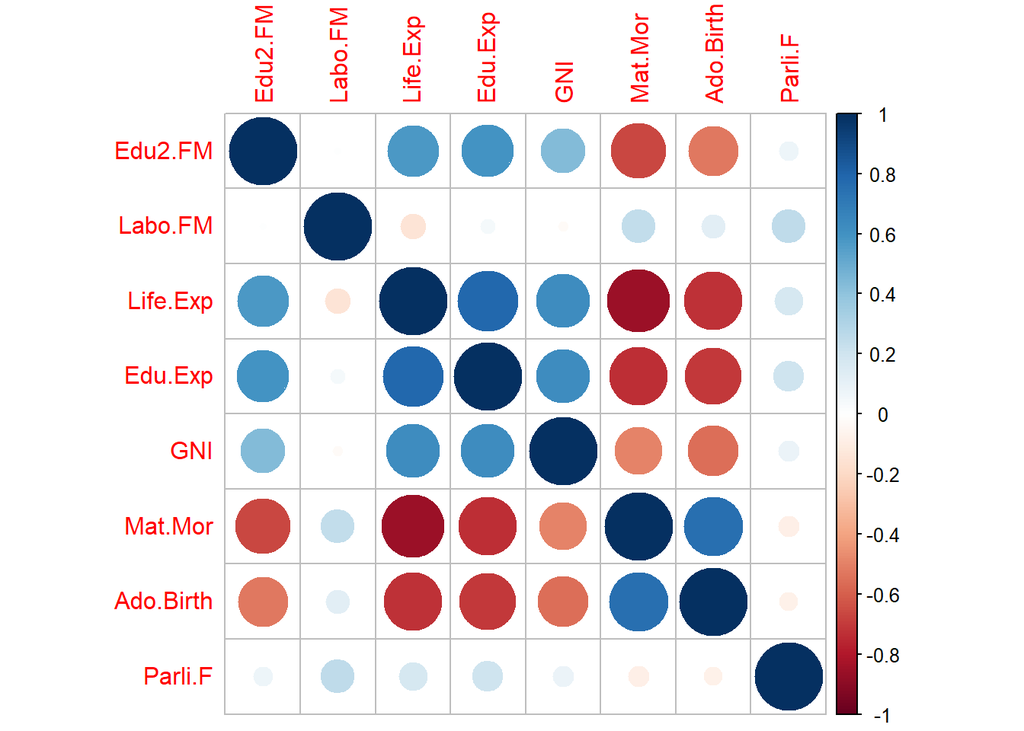

```r
corrplot(cor(human_))
```

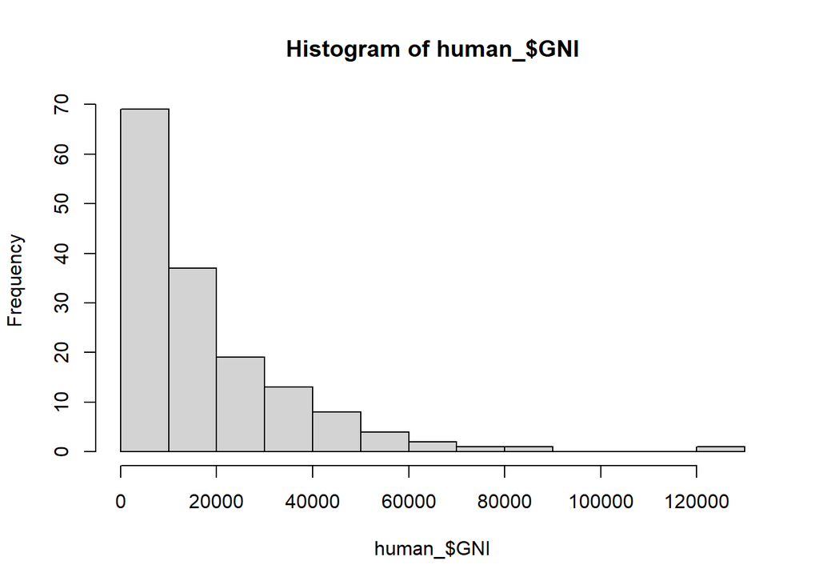

```r
hist(human_$GNI)
```

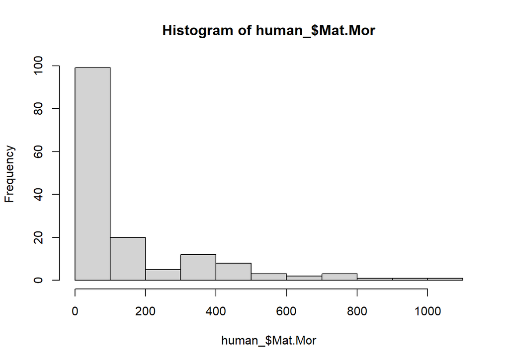

```r
hist(human_$Mat.Mor)
```

GNI and maternal mortality are substantially skewed right. The rest of the variables are reasonably normal regarding skewness and kurtosis values.

Maternal mortality and Adolescent birthrate correlate positively with each other and negatively with Life expectancy, Education, GNI and ratio of secondary education between genders, which form another intercorrelated cluster.

Representation in Parliament and Labor role participation ratio between genders do not correlate with other variables.

### Part 2: PCA on raw data

Calculate and visualize PCA

```r
pca_human <- prcomp(human_)
s <- summary(pca_human)
round(1*s$importance[2, ], digits = 2)
```

```
## PC1 PC2 PC3 PC4 PC5 PC6 PC7 PC8
##   1   0   0   0   0   0   0   0
```

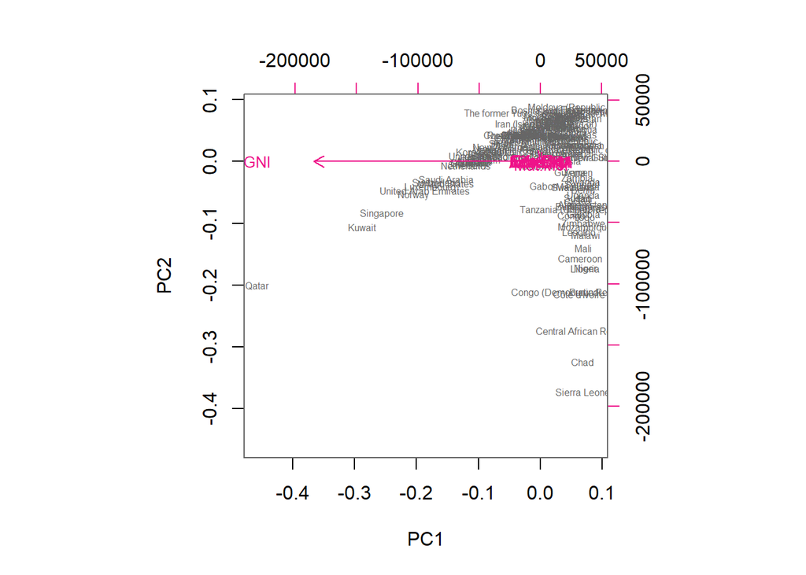

```r
biplot(pca_human, cex = c(0.5, 0.8), col = c("grey40", "deeppink2"))
```

### Part 3: PCA on scaled data

Calculate and visualize PCA using normalized variables

```r
pca_human_z <- prcomp(scale(human_))
s_z <- summary(pca_human_z)
pca_pr_z <- round(100*s_z$importance[2, ], digits = 2)
pca_pr_z
```

```
##   PC1   PC2   PC3   PC4   PC5   PC6   PC7   PC8
## 53.61 16.24  9.57  7.58  5.48  3.60  2.63  1.30
```

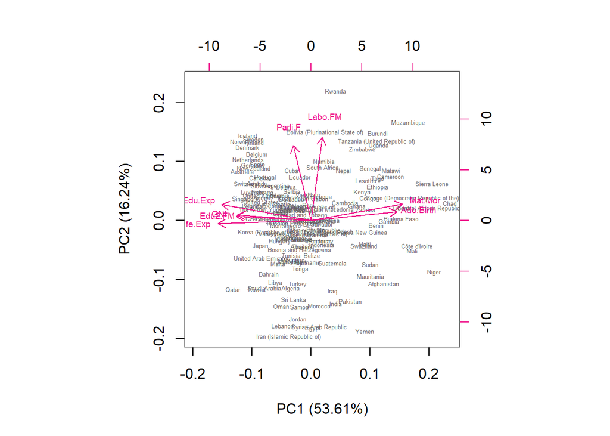

```r
pc_lab<-paste0(names(pca_pr_z), " (", pca_pr_z, "%)")
biplot(pca_human_z, cex = c(0.4, 0.6), col = c("grey40", "deeppink2"),xlab=pc_lab[1],
       ylab=pc_lab[2])
```

*Caption for Figure: PC1 can be interpreted to represent the (negative) development level and prosperity of the society, PC2 represents gender equality. Numbers in parentheses represent accounted variance by the component*

With unstandardized variables, GNI dominates the whole analysis, accounting for 99.99% of variance via the first component, making the analysis useless. It is clearly very important to scale the variables when doing dimensionality reduction!

With standardized variables, we get two components accounting for ~70% of the total variance and possible interpretations.

### Part 4: Interpretation of the components

Component 1 can be interpreted to represent (negative) prosperity. It is positively loaded by maternal mortality and adolescent birthrate, and negatively loaded by education and human development index.

component 2 can be interpreted to represent gender equality, loaded by parliamentary representation of females and labor force participation ratio between the sexes.

Components are orthogonal, indicating the they are, to a degree, independent factors withing countries.

### Part 5: It’s teatime!

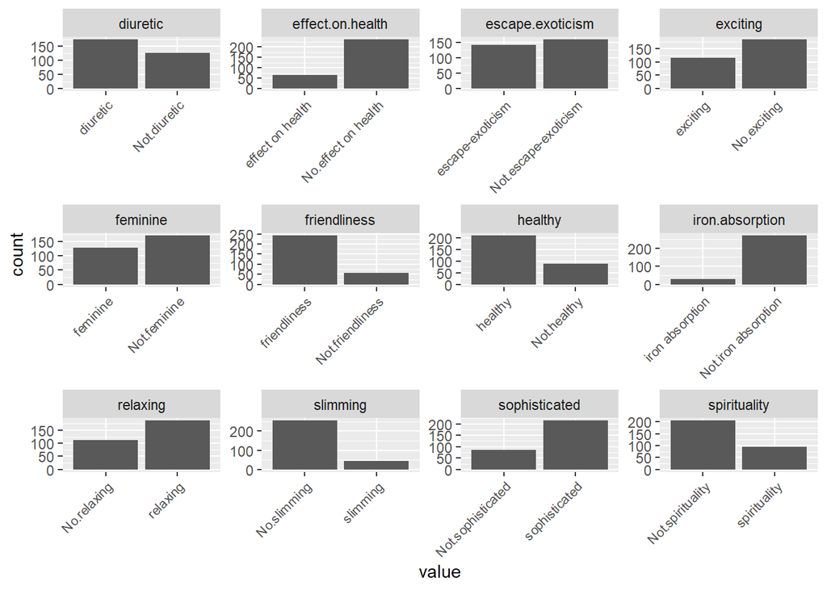

```r
#read the data
tea <- read.csv("https://raw.githubusercontent.com/KimmoVehkalahti/Helsinki-Open-Data-Science/master/datasets/tea.csv", stringsAsFactors = TRUE)

#check data, comment out
#view(tea)

#Let's use the perception variables from the last 12 columns of the data
tea_perc<-tea[,25:36]

#plot the responses
pivot_longer(tea_perc, cols = everything()) %>%
  ggplot(aes(value)) + geom_bar()+ facet_wrap("name", scales = "free")+ theme(axis.text.x = element_text(angle = 45, hjust = 1, size = 8))
```

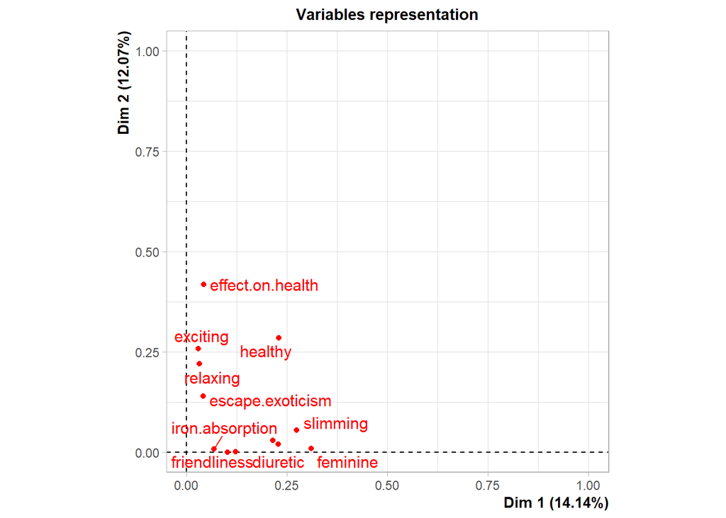

```r
#run MCA
mca <- MCA(tea_perc, graph = TRUE)
```

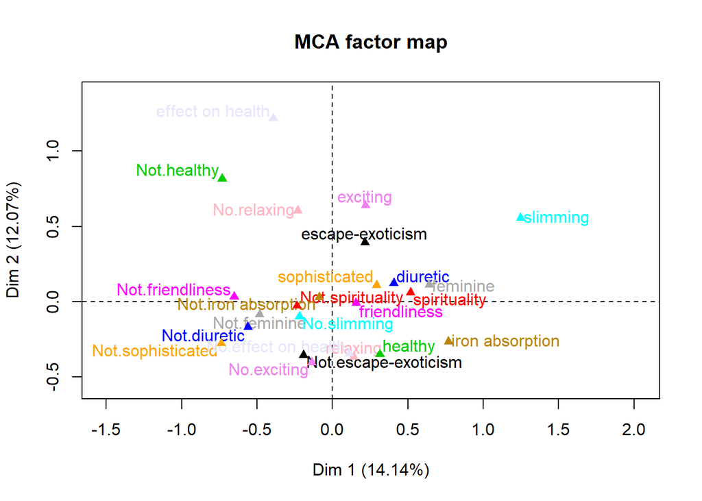

```r
#plot the biplot
plot(mca, invisible=c("ind"), graph.type = "classic", habillage = "quali")
```

MCA was conducted on the variables detailing the perception of tea brands.

The two-component solution explains only quarter of the variance. The first dimension can be interpreted as positive/feminine vs negative/non-feminine definition of the product (DEFINITIONS). Second dimensions concerns health, excitability and vigour (EFFECTS).

More research is needed….